# R Notebook

## This is the workflow for reading in TRACER output to an existing Seurat object

load libraries

```r
library(Seurat)
```

Load Seurat obj

```r
rm(list=ls())
load("/myVolume/sclung_adeno/R_objects/04_main_seurat_subset_190128_immune_annotated.RData")
```

```r
dim(tiss_subset@meta.data)
```

```
[1] 21444    65
```

[figure not shown]

```r
colnames(tiss_subset@meta.data)
```

```
 [1] "nGene"                        "nReads"                       "orig.ident"                   "well"
 [5] "plate"                        "cell_id"                      "sample_name"                  "patient_id"
 [9] "DOB"                          "gender"                       "race"                         "smokingHx"
[13] "histolgy"                     "driver_gene"                  "driver_mutation"              "secondary_mutation"
[17] "Notes"                        "stage.at.dx"                  "pathlogy_review"              "biopsy_date"
[21] "sort_date"                    "biopsy_type"                  "biopsy_site"                  "primary_or_metastaic"
[25] "biopsy_time_status"           "early_treatment_status"       "best_rxn_status"              "biopsy_timing"
[29] "analysis"                     "treatment_history"            "treatment_history_detail"     "line_of_therapy"
[33] "treatment_type"               "treatment"                    "percent_PFS_ref_values"       "percent.PFS.reference.values"
[37] "infections"                   "early_bx_day"                 "treatment_start_date"         "pfs_over_under"
[41] "pfs_day"                      "pfs_month"                    "date_of_death"                "stageIII.IV_ca_dx_date"
[45] "ca_dx_OS"                     "percent.ercc"                 "percent.ribo"                 "res.0.1"
[49] "res.0.3"                      "res.0.5"                      "res.0.7"                      "res.0.9"
[53] "S.Score"                      "G2M.Score"                    "Phase"                        "immune_annotation"
[57] "main_seurat_cluster"          "general_annotation"           "immune_subtype_annotation"    "T_cell_subtype_annotation"
[61] "Final_immune_annotation"      "A_productive"                 "B_productive"                 "clonal_group_AB"
[65] "group_size_AB"
```

```r
unique(tiss_subset@meta.data$Final_immune_annotation)
```

```
 [1] "immune/Myeloid"                     "non-immune"                         "immune/T-cells/CD4.Naive"
 [4] "immune/Dendritic"                   "immune/T-cells/CD8.cytotoxic_IFNG"  "immune/B-cells-PB"
 [7] "immune/T-cells/CD8_cytotoxic_GZMK"  "immune/T-cells/CD4.Treg"            "immune/Mast"
[10] "immune/Neutrophils"                 "immune/B-cells-M"                   "immune/T-cells/Neg.unknown"
[13] "immune/T-cells/CD4.TH"              "immune/T-cells/mixed.exhausted_PD1" "immune/pDCs"
[16] "immune/NK-cells"                    "immune/T-cells/CD8_cytotoxic_GZMB"
```

Read in Tracer data

```r
# A/B summary
tracer_summary <- read.csv("/myVolume/TCR_assembly_pipeline/filtered_TCRAB_summary/cell_data.csv", header = T)
```

Lets define a new metadata df and add some new cols

```r
meta_edit <- tiss_subset@meta.data
meta_edit$A_productive <- NA
meta_edit$A_productive <- as.vector(meta_edit$A_productive)
meta_edit$B_productive <- NA
meta_edit$B_productive <- as.vector(meta_edit$B_productive)
meta_edit$clonal_group_AB <- NA
meta_edit$group_size_AB <- NA
```

Make sure cell IDs look the same

```r
tracer_summary$cell_name <- gsub("[.]", "_", tracer_summary$cell_name)
```

find cell name matches btwn meta_edit and tracer_summary this match() function is so much more efficient that looping!!

```r
match_vec <- match(row.names(meta_edit), tracer_summary$cell_name) # meta_edit first
match_vec1 <- match(tracer_summary$cell_name, row.names(meta_edit)) # tracer_summary first
length(match_vec)
```

```
[1] 21444
```

```r
length(match_vec1)
```

```
[1] 3894
```

```r
head(match_vec)
```

```
[1] NA NA NA  1 NA NA
```

```r
length(unique(match_vec))
```

```
[1] 3695
```

add tracer_summary info to meta_edit, based on cell name matches

```r
for (i in 1:length(match_vec)){
  currIndex <- match_vec[i]
  meta_edit$A_productive[i] <- as.vector(tracer_summary$A_productive[currIndex])
  meta_edit$B_productive[i] <- as.vector(tracer_summary$B_productive[currIndex])
  meta_edit$clonal_group[i] <- as.vector(tracer_summary$clonal_group[currIndex])
  meta_edit$group_size[i] <- as.vector(tracer_summary$group_size[currIndex])
}
```

now export to csv

```r
write.csv(meta_edit, "/myVolume/sclung_adeno/immune_cell_analysis/data_out/I06/metadata_with_assembled_TCRs.csv")
```

add to metadata of Seurat object

```r
table(tiss_subset@meta.data$clonal_group)
```

```
  0   1   2   3   4   5   6   7   8   9  10  12  13  14  15  16  18  19  20  21  22  23  24  25  26  27  28  29  30  31  32  33  34  35  36  37
 17   2  16   3   3   2   3   3  36   2   9   8   2   5   3   2   3   2   2  27   2   3   2   2   3   2   3   2   8   2   2   2   2   2   6   3
 38  39  40  41  42  43  44  45  46  47  48  49  50  51  52  53  54  55  56  57  58  59  60  61  62  63  65  66  67  68  69  70  71  72  73  74
 31   2   8   3   2   3   8   2   2   8   3   5   2   6  11   2   2   2   5   2   3   3   2   2   3   2   5   2   4   2   3   5   3   2   3   2
 75  76  77  78  79  80  81  82  83  84  85  86  87  88  89  90  91  92  93  94  95  97  98  99 100 101 102 103 104 105 106 107 108 109 111 112
  2   4   2   3   2   2   2   2   3   4   1   2   2   2   2   3   6   2   5   4   2   7   7   2   2   2   2   1   2   2   2   2   7   3   4   3
113 114 115 116 117 118 119 120 121 122 123 124 125 126 127 128 129 130 131 132 133 134 135 136 137 138 139 141 142 143 144 145 146 147 148 149
  2   2   2   2   2   2   2   4   3   2   9   6   3   2   3   2   2   2   2   3   2   8   2   2   2   3   2   2   2   2   3   2   2   2   2   2
150 151 152 153 154 155 156 157 158 159 160 161 162 164 165 166 167 168 169 170 171 172 173 174 175 176 177 178 179 180 182 185 186 187 188 189
  4   3   2   3   2   3   3   3   2   2   2   1   2   2   2   2   4   2   6   2   2   2   2   2   2   2   2   2   3   2   2   3   3   2   2   2
190 191 192 193 194 195 196 197 198 199 200 201 202 203 204 205 206 207 208 209 210 211 212 213 214 215 216 217 218 219 220 221 222 223 224 225
  2   2   3   2   4   2   2   2   3   2   1   2   2   2   3   2   2   2   5   2   2   2   2   2   2   2   2   2   2   2   2   2   3   2   3   4
226 227 228 229 230 231 232 233 234 235 236 237 238 239 240 241 242 243 244 245 246 247 248 249 250 251 252 253 254 255 256 257 258 259 260 261
  2   2   2   2   2   2   2   1   2   2   2   2   2   2   2   4   2   4   2   2   2   2   2   2   3   2   2   2   2   2   2   2   2   2   2   2
262 263 264 265 266 267 268 269 270 271 272
  2   2   3   2   2   2   3   2   2   2   2
```

Save Seurat obj

```r
save(tiss_subset, file = "/myVolume/sclung_adeno/R_objects/04_main_seurat_subset_190128_immune_annotated.RData")
```

Subset immune data

```r
tiss_subset_Tclonality
```

```
An object of class seurat in project SeuratProject
 26485 genes across 12093 samples.
```

Rename NAT cells to the same patient name For the purposes of T-cell clonality the fact that they are not from the tumor core is not relevant

```r
tiss_subset_Tclonality@meta.data$patient_id[grep("NAT", tiss_subset_Tclonality@meta.data$patient_id)] <- gsub("_NAT", "", tiss_subset_Tclonality@meta.data$patient_id[grep("NAT", tiss_subset_Tclonality@meta.data$patient_id)])
```

Counting the total number of clonotypes containing more than 2 T-cells per treatment group

|  | value | Var1 |
| --- | --- | --- |
| grouped_pd | 150 | grouped_pd |
| grouped_pr | 66 | grouped_pr |
| naive | 69 | naive |

Counting the number of T-cells that are part of clonotypes across treatment groups as a fraction of total T-cells in each group

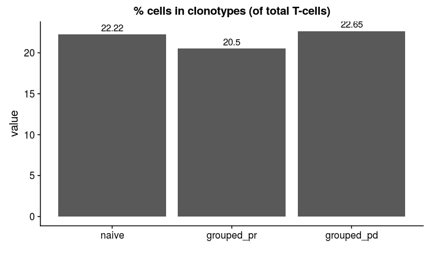

Histogram of clonotype sizes

```r
tab.1 <- table(tiss_subset_Tclonality@meta.data$clonal_group, tiss_subset_Tclonality@meta.data$analysis)
tab.1 <- as.data.frame(melt(tab.1))
# remove zeros
tab.1 <- tab.1[tab.1$value != 0,]
# Reorder factor
tab.1$Var.2 <-  factor(tab.1$Var.2, levels = c("naive", "grouped_pr", "grouped_pd"))
df <- tab.1 %>% group_by(Var.2) %>% dplyr::summarize(Mean = mean(value, na.rm=TRUE))
# Plot per treatment group
p <- ggplot(tab.1, aes(x = Var.2, y = value)) +
      geom_jitter() + labs(x="", y="Clonotype size") +
      geom_errorbar(data=df, aes(y=NULL, ymax=Mean, ymin=Mean), colour="firebrick")
ggsave("/myVolume/sclung_adeno/immune_cell_analysis/plot_out/I06/T-cell_clonotype_size_by_treatment.pdf", width = 7, height = 5, plot=p)
# Plot a histogram with all sizes
q <-ggplot(tab.1, aes(x=value)) +
    geom_histogram(color="black", fill="white", bins = 50) +
    labs(x="Clonotype size")
ggsave("/myVolume/sclung_adeno/immune_cell_analysis/plot_out/I06/All_T-cell_clonotype_sizes.pdf", width = 7, height = 5, plot=q)
```

```r
# Test significance of size distribution
pairwise.wilcox.test(x = tab.1$value, g = tab.1$Var.2)
```

```
    Pairwise comparisons using Wilcoxon rank sum test

data:  tab.1$value and tab.1$Var.2

           naive grouped_pr
grouped_pr 0.36  -
grouped_pd 0.78  0.19

P value adjustment method: holm
```

Look for correlation with T-cell Subtype

```r
tab.1 <- table(tiss_subset_Tclonality@meta.data$T_cell_subtype_annotation,tiss_subset_Tclonality@meta.data$clonal_group)
pdf("/myVolume/sclung_adeno/immune_cell_analysis/plot_out/I06/Clonotypes_and_subtypes_heatmap.pdf", width = 15,height = 10)
heatmap.2(log2(tab.1+1), trace = "n", Rowv=T, Colv=F, col = viridis(100),
          hclustfun = function(x) hclust(x, "ward.D2"), margins = c(10,15),
          key.title="log2 cell counts + 1")
```

```
Discrepancy: Colv is FALSE, while dendrogram is `both'. Omitting column dendogram.
```

```r
dev.off()
```

[figure not shown]

Plot the actual sequences within the clonotypes that are shared between patients

```r
# source("https://bioconductor.org/biocLite.R")
# biocLite("msa")
require(msa)
require(tools)
require(latexpdf)
require(Biobase)
# Which clonotypes contain cells from multiple patients ?
tab.1 <- table(tiss_subset_Tclonality@meta.data$patient_id,tiss_subset_Tclonality@meta.data$clonal_group)
tab.1[tab.1 !=0] <- 1
inter.p.clonos <- names(which(colSums(tab.1) > 1))
# Subset those cell only
metadata <- tiss_subset_Tclonality@meta.data
meta.temp.inter <- metadata[metadata$clonal_group %in% inter.p.clonos,]
```

Fixing weird parssing issue with some of the TRACER output naming of A and B productive chains

[output not shown]

[output cut: 45 more lines]

```r
pdf("/myVolume/sclung_adeno/immune_cell_analysis/plot_out/I06/Interpatient_clonotypes_baloonplot.pdf",width = 15,height = 10)
balloonplot(table(as.character(meta.temp.inter$patient_id),meta.temp.inter$clonal_group),
            xlab ="Patient_ID", ylab="Clonotype",
            label = T, show.margins = F,
            text.size=1, main="Interpatient clonotypes")
dev.off()
```

Plot actual CDR3 sequences for interpatient clonotypes Use TCRA and TCRB productive chains

```r
meta.temp.inter$cell_name <- row.names(meta.temp.inter)
for(i in inter.p.clonos){
meta.temp.temp <- meta.temp.inter[meta.temp.inter$clonal_group == i,]
# Align TCR As
a.vec <- meta.temp.temp$A_productive
names(a.vec) <- paste(meta.temp.temp$patient_id, meta.temp.temp$cell_name, sep = "//")
a.list <- strsplit(as.character(a.vec), "_")
names(a.list) <- names(a.vec)
secs <- do.call(rbind,a.list)[,2]
# Do not plot if there are less than 2 sequences
if(length(secs) > 1)
{
# names(secs) <- meta.temp.temp$patient_id
al_A <- msa(inputSeqs = secs, type = "dna")
#
tmpFile <- paste0(paste("/myVolume/sclung_adeno/immune_cell_analysis/plot_out/I06/tex_files/interpatient_T_clonos/clonotype",i,"TCR-A",sep="_"),".tex")
  file.create(tmpFile)
  msaPrettyPrint(al_A, file=tmpFile, output="tex",
               showNames="left", showNumbering="none", showLogo="top",
               showConsensus="bottom", logoColors="rasmol",
               verbose=FALSE, askForOverwrite=FALSE, paperWidth=7, paperHeight = 9,
               shadingMode="identical", shadingColors = "reds", consensusColors = "Gray",
               showLegend=F)
}
# Align TCR Bs
a.vec <- meta.temp.temp$B_productive
names(a.vec) <- paste(meta.temp.temp$patient_id, meta.temp.temp$cell_name, sep = "//")
a.list <- strsplit(as.character(a.vec), "_")
names(a.list) <- names(a.vec)
secs <- do.call(rbind,a.list)[,2]
# Do not plot if there are less than 2 sequences
if(length(secs) > 1)
{
al_B <- msa(inputSeqs = secs, type = "dna")
#
tmpFile <- paste0(paste("/myVolume/sclung_adeno/immune_cell_analysis/plot_out/I06/tex_files/interpatient_T_clonos/clonotype",i,"TCR-B",sep="_"),".tex")
  file.create(tmpFile)
  msaPrettyPrint(al_B, file=tmpFile, output="tex",
               showNames="left", showNumbering="none", showLogo="top",
               showConsensus="bottom", logoColors="rasmol",
               verbose=FALSE, askForOverwrite=FALSE, paperWidth=7, paperHeight = 9,
               shadingMode="identical", shadingColors = "reds", consensusColors = "Gray",
               showLegend=F)
}
}
```

[output not shown]

```r
al_A
```

```
CLUSTAL 2.1

Call:
   msa(inputSeqs = secs, type = "dna")

MsaDNAMultipleAlignment with 2 rows and 10 columns
    aln        names
[1] GGACGGAGGA TH266//K21_B002571
[2] GGACGGAGGA TH226//C10_B003191
Con GGACGGAGGA Consensus
```

```r
a.vec
```

```
[1]
438 Levels:  TRAV10_AGGGGCTCTATGG_TRAJ47 TRAV10_GAGCGCGACAATGC_TRAJ39 ... TRDV1_TGGGGGTGTATAACT_TRAJ57
```

Analysis of persistent clonotypes aligning productive TCRa and b

Find the patients with multiple biopsies

```r
pdf("/myVolume/sclung_adeno/immune_cell_analysis/plot_out/I06/Patients_with_multiple_biopsies_Immune_cell_counts.pdf", width = 10, height = 7)
balloonplot(t(tab.2), main ="Patients with multiple biopsies", xlab ="", ylab="",
label = T, show.margins = F)
dev.off()
```

Plot the number of T-cells in clonotypes for each patient with multiple biopsies

```r
require(gtools)
require(reshape2)
# Proceed to analyzaing patients with multiple biopsies in terms of TCR content
# pers.patients <- c("TH179", "TH185", "TH218", "TH226", "TH231", "TH248", "TH266")
meta.temp.pers <- meta.temp[meta.temp$patient_id %in% pers.patients,]
# Make a table with clonotypes
tab.1 <- table(meta.temp.pers$new.id,meta.temp.pers$clonal_group)
tab.2 <- table(meta.temp.pers$new.id.2,meta.temp.pers$clonal_group)
# Iterate for each patient
ggplot.pers.pat <- list()
for(i in 1:length(pers.patients))
{
  # Subset the table
  tab.1.temp <- tab.2[grep(pers.patients[i], rownames(tab.2)),]
  # Assuming there are remaining cells in that patient
  if(length(which(colSums(tab.1.temp) == 0)) < ncol(tab.1.temp)-1)
    {
  # Remove clonotype with no cells for this patient
  tab.1.temp <- tab.1.temp[,colSums(tab.1.temp) != 0  ]
  # Print message
  message(paste(pers.patients[i], "has cells in clonotypes"))
  # Melt the table to long format
  tab.1.long <- melt(tab.1.temp)
  # Convert clonotype number to factor and sort new patient Ids on date
  tab.1.long$Var.2 <- factor(tab.1.long$Var.2, levels = unique(tab.1.long$Var.2))
  tab.1.long$Var.1 <- factor(tab.1.long$Var.1, levels = mixedsort(as.character(unique(tab.1.long$Var.1)), decreasing = T))
  # Plot
  p <- ggplot(tab.1.long, aes(x = Var.1, y = Var.2)) +
  geom_point(data=tab.1.long,aes(x=Var.1, y=Var.2,size = ifelse(value==0, NA, value))) +
  geom_hline(yintercept = c(1:length(unique(tab.1.long$Var.2))), linetype = "dashed", colour="grey90") +
  geom_point(data=tab.1.long,aes(x=Var.1, y=Var.2,size = ifelse(value==0, NA, value))) +
  xlab("patient timepoint") + ylab("clonotype ID") +
  theme(axis.text.x = element_text(angle=45, vjust = 0.5)) +
  labs(size="Ncells")
  # Store plot for each patient
  ggplot.pers.pat[[i]] <- p
  }
  else {message(paste(pers.patients[i], "has no cells in clonotypes"))}
}
# Plot number of cells in persistent clonotypes across patients with multiple biopsies
ggplot.pers.pat <- ggplot.pers.pat[which(lapply(ggplot.pers.pat, is.null) == F)]
ggsave("/myVolume/sclung_adeno/immune_cell_analysis/plot_out/I06/Persistent_T-clonotypes_per_patient.pdf", gridExtra::marrangeGrob(grobs = ggplot.pers.pat, nrow=1, ncol=1))
```

```r
difftime(time1 = strptime("19.07.2018", format = "%d.%m.%Y"),
         time2 = strptime("03.08.2018", format = "%d.%m.%Y"), units = "days")
```

```
Time difference of -15 days
```